# Title: Reproducible Research: Peer Assessment Two

Dr Paul Fergus

24/10/2014

## Summary

It is common knowledge that stroms and severe weather conditions have a serious impact on public health and the economy. There is a general consensus that the utilisation of data will help to inform and prioritise decisions about if and when they could occur, including estimates of potential fatalities, injury and damage to proporty. This report draws the readers attention to this fact and presents quantitative evidence based on a storm database collected from the U.S. Oceanic and Atmospheric Administration (NOAA) from 1950-2011.

## Synopsis

### Load Libraries and Perform Initial Setup

```r
#Load Libraries
library(ggplot2)
library(plyr)
#This allows the reader to examine the software environment
```

### Load Data

```r
if(!file.exists("./data/repdata-data-StormData.csv")){
  dataset <- read.table(
    bzfile("./data/repdata-data-StormData.csv.bz2",
      "repdata-data-StormData.csv"), sep=",", header=T, na.string="NA")
}
```

### Check that we have data

At this stage we just want to check that we have loaded some data.

```r
head(dataset, n=1)
```

```
##   STATE__          BGN_DATE BGN_TIME TIME_ZONE COUNTY COUNTYNAME STATE
## 1       1 4/18/1950 0:00:00     0130       CST     97     MOBILE    AL
##    EVTYPE BGN_RANGE BGN_AZI BGN_LOCATI END_DATE END_TIME COUNTY_END
## 1 TORNADO         0                                               0
##   COUNTYENDN END_RANGE END_AZI END_LOCATI LENGTH WIDTH F MAG FATALITIES
## 1         NA         0                        14   100 3   0          0
##   INJURIES PROPDMG PROPDMGEXP CROPDMG CROPDMGEXP WFO STATEOFFIC ZONENAMES
## 1       15      25          K       0
##   LATITUDE LONGITUDE LATITUDE_E LONGITUDE_ REMARKS REFNUM
## 1     3040      8812       3051       8806              1
```

## Data Preprocessing

I left completing this assignment far too late. I would have liked to have cleaned the data more than I have. In particular, the final set of results caused problems becuase of dupiliate EVTYPE data values- please see the numeric values - I should have dealt with these values in the preprocessing stage, but have not due to time constraints.

What has been done is to convert the alpha values that represent thousands, millions and billions,into numerical equivalents so that we can calculate the property and crop damage. For this project I have capped the number of events that we are interested in to the top ten as these account for most of the damage and costs.

During this stage we also work out which weather event causes the most loss of life and injury and which of the weather events recorded has the most significant ecomonic impact on property and crops

```r
#PROPDMGEXP
#Convert the exponential to a numeric value that we can work with.
dataset$PROPDMGEXP <- as.character(dataset$PROPDMGEXP)
dataset$PROPDMGEXP[grep("K", dataset$PROPDMGEXP)] <- "1000"
dataset$PROPDMGEXP[grep("k", dataset$PROPDMGEXP)] <- "1000"
dataset$PROPDMGEXP[grep("M", dataset$PROPDMGEXP)] <- "1000000"
dataset$PROPDMGEXP[grep("m", dataset$PROPDMGEXP)] <- "1000000"
dataset$PROPDMGEXP[grep("B", dataset$PROPDMGEXP)] <- "1000000000"
dataset$PROPDMGEXP[grep("b", dataset$PROPDMGEXP)] <- "1000000000"
#Set all other characters to 1 - we consider this to be noise in the data.
to.be.one <- dataset$PROPDMGEXP %in% c("1000", "1000000", "1000000000") == F
dataset$PROPDMGEXP[to.be.one == TRUE] <- "1"
#Change the variable to numeric so that we can perform the calculations
dataset$PROPDMGEXP <- as.numeric(dataset$PROPDMGEXP)

#CROPDMGEXP
#Convert the exponential to a numeric value that we can work with.
dataset$CROPDMGEXP <- as.character(dataset$CROPDMGEXP)
dataset$CROPDMGEXP[grep("K", dataset$CROPDMGEXP)] <- "1000"
dataset$CROPDMGEXP[grep("k", dataset$CROPDMGEXP)] <- "1000"
dataset$CROPDMGEXP[grep("M", dataset$CROPDMGEXP)] <- "1000000"
dataset$CROPDMGEXP[grep("m", dataset$CROPDMGEXP)] <- "1000000"
dataset$CROPDMGEXP[grep("B", dataset$CROPDMGEXP)] <- "1000000000"
dataset$CROPDMGEXP[grep("b", dataset$CROPDMGEXP)] <- "1000000000"
#Set all other characters to 1 - we consider this to be noise in the data.
to.be.one <- dataset$CROPDMGEXP %in% c("1000", "1000000", "1000000000") == F
dataset$CROPDMGEXP[to.be.one == TRUE] <- "1"
#Change the variable to numeric so that we can perform the calculations
dataset$CROPDMGEXP <- as.numeric(dataset$CROPDMGEXP)

#Calculate the costs
dataset$prop.damage <- dataset$PROPDMG * dataset$PROPDMGEXP
dataset$crop.damage <- dataset$CROPDMG * dataset$CROPDMGEXP

#Extract the top 10 most
top.ten.prop <- head(dataset[order(dataset$prop.damage, decreasing=TRUE),], 10)
top.ten.crop <- head(dataset[order(dataset$crop.damage, decreasing=TRUE),], 10)

#First of all summerise all the fatalities and injuries for all of the event types in the dataset.
casulties <- ddply(dataset, .(EVTYPE), summarize,
                   fatalities = sum(FATALITIES),
                   injuries = sum(INJURIES))

#Get the top 10  event types that cause fatality.
top.ten.fatalities <- head(casulties[order(casulties$fatalities, decreasing=TRUE), ], 10)

#Get the top 10  event types that cause fatality.
top.ten.injuries <- head(casulties[order(casulties$injuries, decreasing=TRUE), ], 10)
```

## Results

### Question One: Across the United States, which types of events (as indicated in the EVTYPE variable) are most harmful with respect to population health

We are not interested in every event type, only the ones that cause the most harm. For the purposes of this study we are only interested in the top 10 Event Types that cause the most harm to the poluation (although this could be changed to suite specific needs).

#### The results below show the top ten number of fatalities and injuries categorised by event type

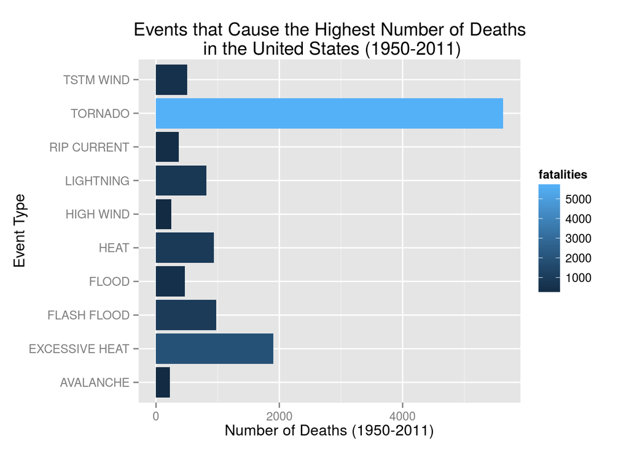

```r
##Top 10 Events that Caused the Highest Number of Deaths
#Plot top ten fatalities by event type
library(ggplot2)
ggplot(top.ten.fatalities, aes(EVTYPE, fatalities, fill=fatalities)) +
  geom_bar(stat="identity") + coord_flip() +
  stat_summary(fun.y = median, geom="bar") +
  labs(x="Event Type", y="Number of Deaths (1950-2011)",
       title="Events that Cause the Highest Number of Deaths\n in the United States (1950-2011)")
```

```r
#Display the top 10 fatalities
top.ten.fatalities[,c("EVTYPE", "fatalities")]
```

```
##             EVTYPE fatalities
## 830        TORNADO       5633
## 123 EXCESSIVE HEAT       1903
## 147    FLASH FLOOD        978
## 269           HEAT        937
## 452      LIGHTNING        816
## 854      TSTM WIND        504
## 164          FLOOD        470
## 581    RIP CURRENT        368
## 354      HIGH WIND        248
## 11       AVALANCHE        224
```

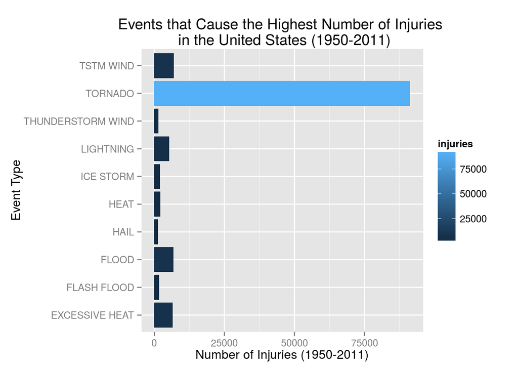

```r
##Top 10 Events that Caused the Highest Number of Injuries
#Plot top ten injuries by event type
ggplot(top.ten.injuries, aes(EVTYPE, injuries, fill=injuries)) +
  geom_bar(stat="identity") + coord_flip() +
  stat_summary(fun.y = median, geom="bar") +
  labs(x="Event Type", y="Number of Injuries (1950-2011)",
       title="Events that Cause the Highest Number of Injuries \n in the United States (1950-2011)")
```

```r
#Display the top 10 fatalities
top.ten.injuries[,c("EVTYPE", "injuries")]
```

```
##                EVTYPE injuries
## 830           TORNADO    91346
## 854         TSTM WIND     6957
## 164             FLOOD     6789
## 123    EXCESSIVE HEAT     6525
## 452         LIGHTNING     5230
## 269              HEAT     2100
## 424         ICE STORM     1975
## 147       FLASH FLOOD     1777
## 759 THUNDERSTORM WIND     1488
## 238              HAIL     1361
```

### Question Two: Across the United States, which types of events have the greatest economic consequences?

[figure not shown]

```r
#Plot the top 10 economoic prop damages
ggplot(top.ten.prop, aes(EVTYPE, prop.damage)) +
  geom_bar(stat="identity") +
  stat_summary(fun.y = median, geom="bar") +
  labs(x="Event Type", y="Cost of Property Damage (in Billions)",
       title="Events that Cause the Highest Property Damage Costs \n in the United States (1950-2011)") +
  theme(axis.text.x = element_text(angle = 45, hjust = 1))
```

```r
#Display the top 10 prop damage
top.ten.prop[,c("EVTYPE", "prop.damage")]
```

```
##                   EVTYPE prop.damage
## 605953             FLOOD   1.150e+11
## 577676       STORM SURGE   3.130e+10
## 577675 HURRICANE/TYPHOON   1.693e+10
## 581535       STORM SURGE   1.126e+10
## 569308 HURRICANE/TYPHOON   1.000e+10
## 581533 HURRICANE/TYPHOON   7.350e+09
## 581537 HURRICANE/TYPHOON   5.880e+09
## 529351 HURRICANE/TYPHOON   5.420e+09
## 443782    TROPICAL STORM   5.150e+09
## 187564      WINTER STORM   5.000e+09
```

[figure not shown]

```r
#Plot the top 10 economoic crop damages
ggplot(top.ten.crop, aes(EVTYPE, crop.damage)) +
  geom_bar(stat="identity") +
  stat_summary(fun.y = median, geom="bar") +
  labs(x="Event Type", y="Cost of Crop Damage (in Billions)",
       title="Events that Cause the Highest Crop Damage Costs \n in the United States (1950-2011)") +
  theme(axis.text.x = element_text(angle = 45, hjust = 1))
```

```r
#Display the top 10 crop damage
top.ten.crop[,c("EVTYPE", "crop.damage")]
```

```
##                   EVTYPE crop.damage
## 198389       RIVER FLOOD  5000000000
## 211900         ICE STORM  5000000000
## 581537 HURRICANE/TYPHOON  1510000000
## 639347           DROUGHT  1000000000
## 312986      EXTREME COLD   596000000
## 422676           DROUGHT   578850000
## 410175           DROUGHT   515000000
## 199733           DROUGHT   500000000
## 337008           DROUGHT   500000000
## 366694         HURRICANE   500000000
```